# Анализ причин оттока клиентов банка

# Исследовательский анализ данных

## Смотрим на соотношение клиентов в разрезе отточности

Для начала рассмотрим соотношение отточных и неотточных клиентов. Для этого подготовим необходимые данные, построим круговую диаграмму и заранее создадим функцию, которая на круговой диаграмме будет отображать как относительные, так и абсолютные значения.

```python
# Готовим данные
churn_df = df.groupby('churn')['churn'].count().to_frame().rename(columns={col:'num_of_clients'}).reset_index()
```

```python
# Функцию make_autopct, которая принимает на вход список значений и возвращает другую функцию my_autopct.
# Функция my_autopct принимает на вход процентное значение и возвращает строку с этим процентным значением и
# Cоответствующим абсолютным значением.

def make_autopct(values):
    def my_autopct(pct):
        # Вычисление суммы всех значений из списка values
        total = sum(values)
        # Вычисление абсолютного значения соответствующего процентному значению pct
        val = int(round(pct*total/100))
        # Возвращение строки с процентным и абсолютным значениями
        return '{p:.0f}%\n({v:d})'.format(p=pct,v=val)
     # Возвращение функции my_autopct как результата работы функции make_autopct
    return my_autopct
```

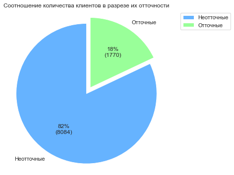

```python
# Строим круговую диаграмму, с необходимыми настройками

sns.set(style="whitegrid")
fig = plt.figure(figsize=(6,6))
plt.pie(churn_df['num_of_clients'],
        labels=['Неотточные', 'Отточные'],
        autopct=make_autopct(churn_df['num_of_clients']),
        startangle=90,
        colors=['#66b3ff','#99ff99'],
        explode=[0, 0.1])
plt.axis('equal')
plt.legend(bbox_to_anchor=(1.05, 1), loc='upper left')
plt.title("Соотношение количества клиентов в разрезе их отточности", fontsize=12)
plt.show()
```

**Вывод:**

Мы видим, что по предоставленным нам данным, банк потерял **18%** или **1770** клиентов от общего числа. Далее попытаемся разобраться в причинах, вызвавших такой отток.

## Рассматриваем распределения данных по каждому признаку в отдельности

df

```python
# Дополняем словарь для заголовков
col_dict_upd = {
    'score':'кредитного скоринга',
     'age':'возраста',
     'balance':'баланса на счете',
     'est_salary':'заработной платы',
     'gender_F':'принадлежности к женскому полу',
     'gender_M':'принадлежности к мужскому полу',
     'city_Rostov':'города Ростова',
     'city_Rybinsk':'города Рябинска',
     'city_Yaroslavl':'города Ярославля'
}

# Объединяем все в один общий словарь
columns_dict = {**col_dict, **col_dict_upd}

# Создаем словарь с подписями для оси X
x_dict = {
    'city': 'Город',
    'gender': 'Пол',
    'equity': 'Оценка собственности',
    'products': 'Кол-во продуктов',
    'credit_card': 'Наличие кредитной карты',
    'last_activity': 'Активность',
    'churn': 'Отточность клиента',
    'score': 'Кредитный скоринг',
    'age': 'Возраст',
    'balance': 'Баланс на счете',
    'est_salary': 'Заработная плата',
    'gender_F': 'Женский пол',
    'gender_M': 'Мужской пол',
    'city_Rostov': 'Город Ростов',
    'city_Rybinsk': 'Город Рябинск',
    'city_Yaroslavl': 'Город Ярославль'
}
```

```python
# Функия на вход принимает датафрейм, высоту и шириту графика, и столбцы по которым не нужнно строить график
# На выохде получаем два графика, где левый - это распределение данных по признаку в разрезе отточности
# А правый - распределение данных по признаку по всем данным

def plot_data(df,h=8,w=16,not_col=[]):

    # Создаем список столбцов для построения гистограммы
    columns = [col for col in df.columns if col not in not_col]

    # Задаем ширину и высоту фигуры
    fig_width = w
    fig_height = h

    # Для каждого столбца из списка columns
    for col in columns:

        # Создаем фигуру с двумя подграфиками (axes)
        fig, axes = plt.subplots(1, 2, figsize=(fig_width, fig_height))

        # Задаем общий заголовок для фигуры
        fig.suptitle('Распределение данных в разрезе ' + columns_dict[col])

        # Строим гистограмму для неотточных клиентов на первом подграфике
        sns.histplot(df[df['churn'] == 0][col], ax=axes[0], color='orange', label='Неотточные', alpha = 0.25)
        # Строим гистограмму для отточных клиентов на первом подграфике
        sns.histplot(df[df['churn'] == 1][col], ax=axes[0], color='lightgreen', label='Отточные', alpha = 0.5)
        # Строим гистограмму для всех данных на втором подграфике
        sns.histplot(df[col], ax=axes[1], color='lightblue')

        # Добавляем необходиые настройки для графика (заголовок, подписи к осям, легенда)
        axes[0].set_title(f'В зависимости от отточности',fontsize=10)
        axes[0].set_xlabel(x_dict[col], fontsize=10)
        axes[0].set_ylabel('Частота', fontsize=10)
        axes[0].legend()
        axes[1].set_title(f'Все данные',fontsize=10)
        axes[1].set_xlabel(x_dict[col], fontsize=10)
        axes[1].set_ylabel('Частота', fontsize=10)

    # Задаем расстояние между подграфиками
    plt.subplots_adjust(hspace=3)
    # Отображаем фигуру
    plt.show()
```

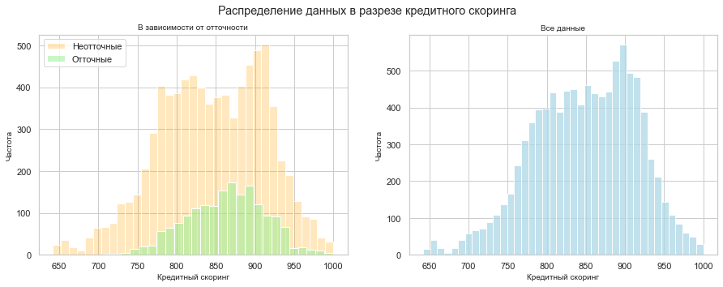

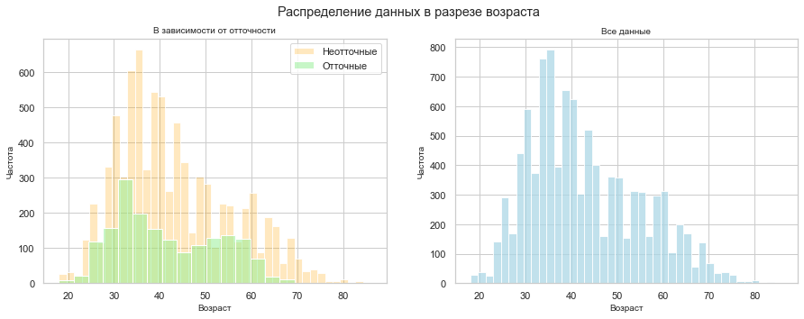

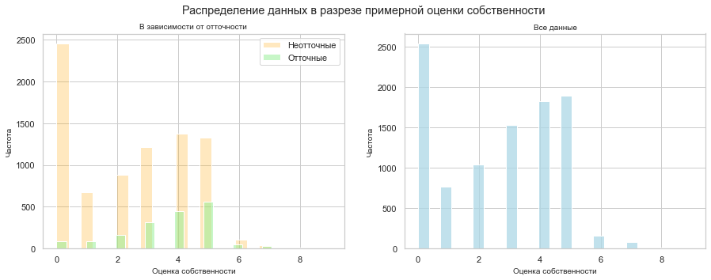

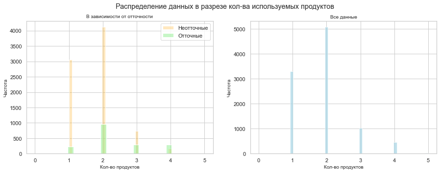

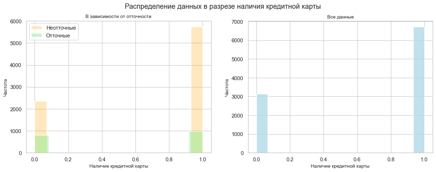

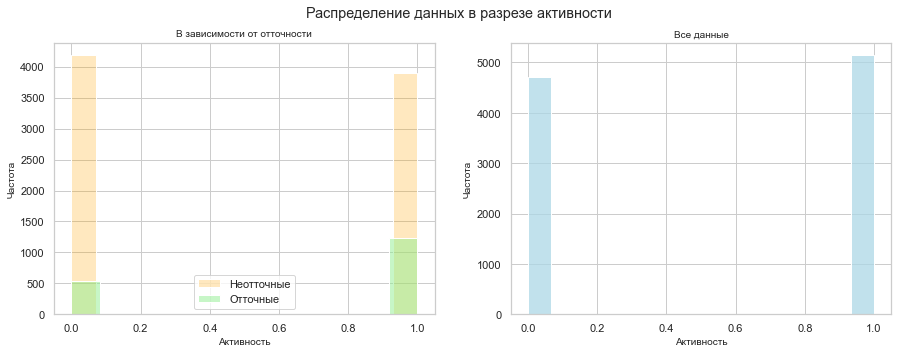

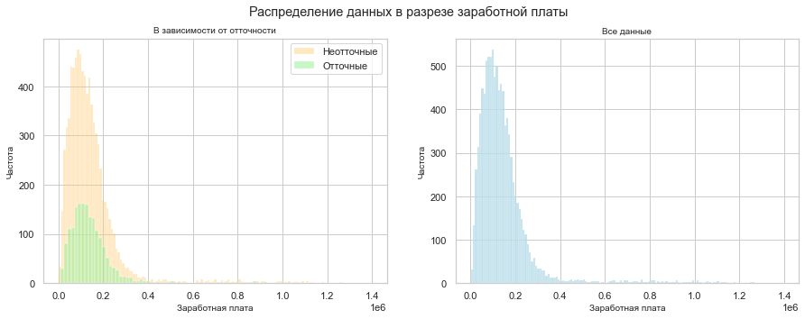

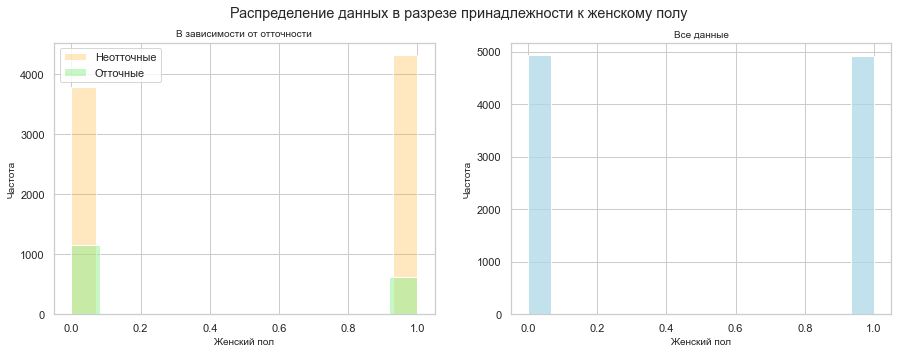

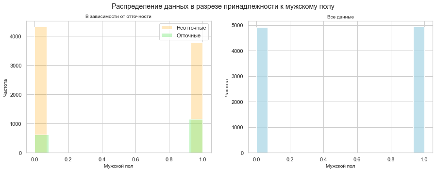

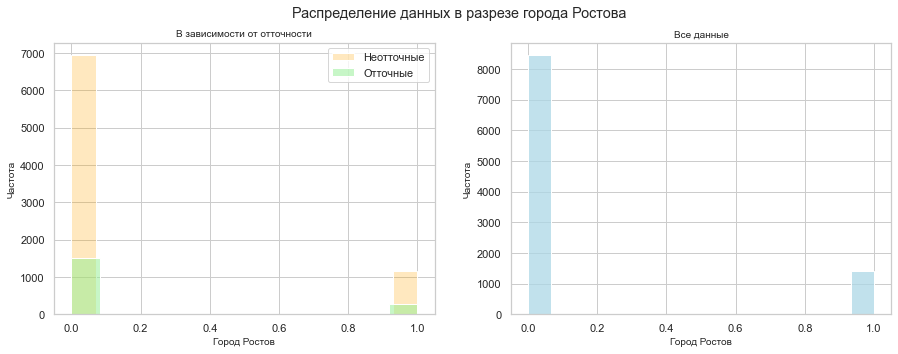

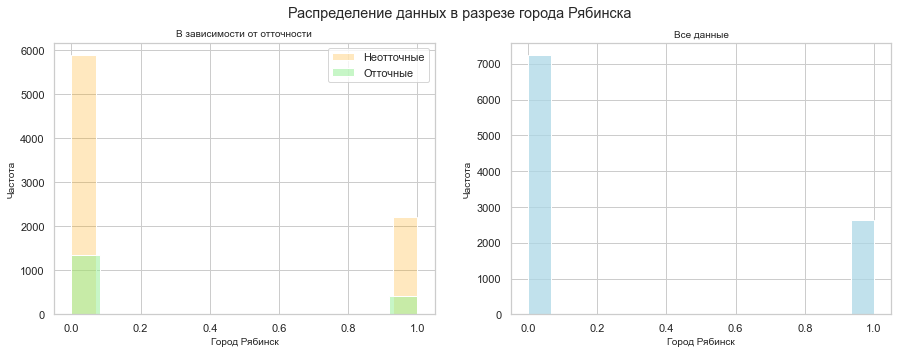

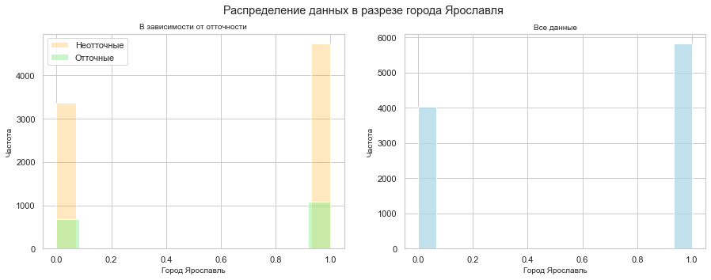

```python
# Строим графики распределения данных для интересующих нас признаков
plot_data(df,h=5,w=15,not_col=['user_id', 'gender', 'city','churn','balance'])
```

Исходя из графиков, мы можем сделать следующие **выводы** о распределении отточности клиентов по признакам:

**Кредитный скоринг**:

- Чаще всего отточными становятся клиенты, имеющие рейтинг в диапазоне от `750-950`;

**Возраст**:

- Больше всего отточных клиентов возрастом от `30-40` и `50-60` лет;

**Примерная оценка собственности**:

- Из банка зачастую уходят клиенты с оценкой собственности в `3-5`;

**Кол-во используемых продуктов**:

- Отточными становятся клиенты имеющие от `2` продуктов и более;

**Активность**:

- Подавляющее большинство отточных клиентов были `активны` последнее время;

**Заработная плата**:

- Клиенты, с зарплатой от `100 тыс` и более чаще становятся отточными;

**Принадлежность к мужскому и женскому полу**:

- `Мужчины` чаще уходят из банка по сравнению с женщинами;

**По городу**:

- Больше всего отточных клиентов среди городов в `Ярославле`.

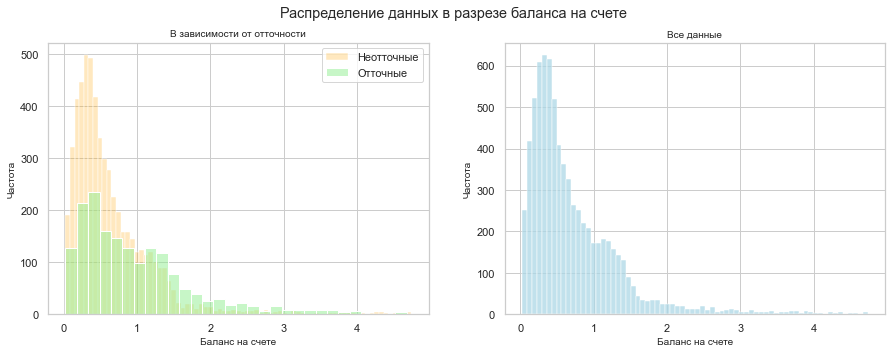

```python
# Для большей наглядности выведем график по распредлению данных в разрезе балана на счете отдельно, убрав "выбивающиеся" значения
# Для большей наглядности

df_balance = df[~df['balance'].isna()][['balance','churn']]
df_balance['balance'] = df_balance['balance']/1000000
df_balance = df_balance[(df_balance['balance'] >= df_balance['balance'].quantile(0.01)) & \
                        (df_balance['balance'] <= df_balance['balance'].quantile(0.99))]


plot_data(df_balance,h=5,w=15,not_col=['churn'])
```

Исходя из графика, мы можем сделать следующие **выводы** об отточности клиентов по признакам:

**Баланс на счете**:

- Зачастую отточными становятся клиенты с балансом в диапазоне от `250 тысяч - 1.5 млн руб`.

## Смотрим на корреляцию признаков

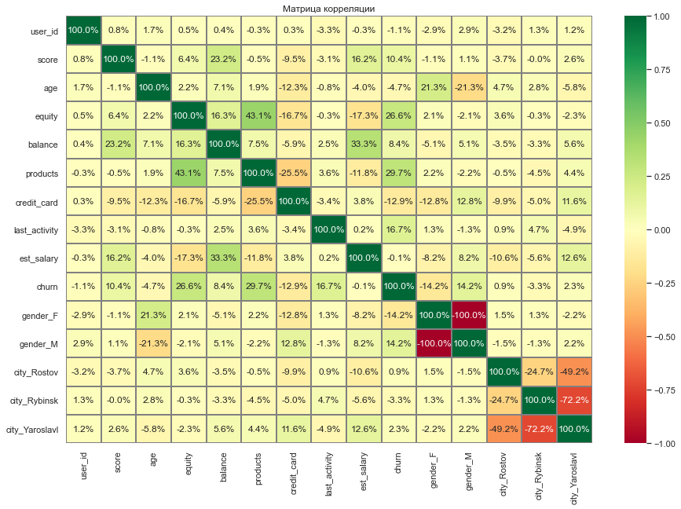

```python
# Для поиска корреляции среди признаков построим матрицу корреляции
fig, ax = plt.subplots(figsize=(15, 10))
plt.title('Матрица корреляции')
sns.heatmap(df.corr(), cmap='RdYlGn', annot = True, fmt='.1%', linewidths=1, linecolor='gray', ax=ax)
plt.show()
```

# Сегментация и составление портрета отточного клиента

Перед проведением сегментирования клиентов, нам нужно подготовить необходимые данные и функции, которые будут использованы для дальнейшего анализа:

Определим диапазоны для категоризации исследуемых нами далее признаков:

**1. Диапазоны возаста** - исходя из графиков распределния из *3 раздела* и категоризации на возрастные группы согласно рекомендациям *ВОЗ* будем учитывать следующие диапазоны и соответствующие категории для возрастов:

- Возраст клиента до 25 лет - `до 25 лет`;
- Возраст клиента c 26 до 49 лет - `От 26 и до 49 лет`;
- Возраст клиента с 50 и до 60 лет - `От 50 и до 60 лет`;
- Возраст клиента старше 60 лет - `Более 60 лет`.

**2. Диапазоны кредитного скорринга:** - исходя из графиков распределния из *3 раздела* и данных по категоризации кредитного рейтинга в РФ (нет единого стандарта, будем считать, что наш банк использует наиболее чатсо используемую систему рейтинга со шкалой от 1 до 1000, в нашем датафрейме минимальный кредитный рейтинг не менее `650`, что уже считается довольно высоким значением) выделим следующие диапазоны и соответствующие категории для кредитного скоринга:

- Кредитный скоринг до 800 - `rating C`;
- Кредитный скорринг с 801-900 - `rating B`;
- Кредитный скорринг более 900 - `rating A`.

**3. Диапазоны заработной платы:** - исходя из графиков распределния из *3 раздела* и данных по средней заработной плате в РФ выделим следующие диапазоны и соответствующие категории заработной платы:

- Заработная плата до 60 тыс руб - `Низкая з/п`;
- Заработная плата с 60-120 тыс руб - `Средняя з/п`;
- Заработная плата со 120-300 тыс руб - `Выше-среднего з/п`;
- Заработная плата более 300 тыс руб - `Высокое з/п`;

**4. Диапазоны баланса на счете:** исходя из графиков распределния из *3 раздела* выделим следующие диапазоны и соответствующие категории по балансу на счете:

- Пустым значения баланса присвоим - `Unknown`;
- Баланс до 250 тыс руб - `Низкий баланс`;
- Балансу от 250 тыс до 1 млн руб - `Средний баланс`;
- Балансу от 1 до 2 млн руб - `Выше-среднего баланс`;
- Балансу более 2 млн руб - `Высокий баланс`.

```python
# Эта функция принимает на вход аргумент age, который представляет собой возраст
# Функция возвращает строку, которая описывает возрастную группу, к которой относится этот возраст

def age_segment(age):

    if age <= 25:
        return 'До 25 лет'
    elif age <= 49:
        return 'От 26 и до 49 лет'
    elif age <= 60:
        return 'От 50 и до 60 лет'
    else:
        return 'Более 60 лет'
```

```python
# Эта функция принимает на вход аргумент - score, который представляет собой значение скоринга
# Функция возвращает строку, которая описывает рейтинговую группу, к которой относится этот скоринг

def scoring_segment(score):

    if score <= 800:
        return 'rating C'
    elif score <= 900:
        return 'rating B'
    else:
        return 'rating A'
```

```python
# Эта функция принимает на вход аргумент - salary, который представляет собой значение зарплаты клиента
# Функция возвращает строку, которая описывает группу по уровню дохода, к которой относится эта зарплата

def salary_segment(salary):

    if salary <= 60000:
        return 'Низкая з/п'
    elif salary <= 120000:
        return 'Средняя з/п'
    elif salary <= 300000:
        return 'Выше-среднего з/п'
    else:
        return 'Высокая з/п'
```

```python
# Эта функция принимает на вход один аргумент - balance, который представляет собой значение баланса на счете
# Функция возвращает строку, которая описывает группу по уровню баланса, к которой относится этот баланс

def balance_segment(balance):

    if math.isnan(balance) == True:
        return 'Unknown'
    elif balance < 250000:
        return 'Низкий баланс'
    elif balance <= 1000000:
        return 'Средний баланс'
    elif balance <= 2000000:
        return 'Выше-среднего баланс'
    else:
        return 'Высокий баланс'
```

```python
# Применяем созданные функции и создаем новые столбцы с сегментами по каждому из этих признаков

df['age_category'] = df['age'].apply(age_segment)
df['scoring_category'] = df['score'].apply(scoring_segment)
df['salary_category'] = df['est_salary'].apply(salary_segment)
df['balance_category'] = df['balance'].apply(balance_segment)
```

```python
# Функция принимает на вход датафрейм и колонку(-и) по которым группирует данные в разрезе кол-во клиентов в сегменте всего
# А также отточных, затем  добавляется колонка с оставшимися в сегменте клиентами
# И вычисляется доля оттока в сегменте, среди всех отточных сегментов, и доля оставшихся

def segment_df(df,col=[]):

    # Группируем данные по столбцам в col и вычисляем количество клиентов в сегменте всего
    # И кол-во отточных клиентов для каждого сегмента
    data = (df.groupby(col)
            .agg({'user_id':'count',
                  'churn':'sum' })
            .reset_index().
            rename(columns={'user_id':'total_users',
                            'churn':'churn_client_num'}))

    # Вставляем новый столбец 'not_churn_client_num' (Не отточные клиенты)
    data.insert(data.columns.get_loc('churn_client_num') + 1, 'not_churn_client_num', \
                data['total_users'] - data['churn_client_num'])

    # Вычисляем долю оттока клиентов среди всех отточных клиентов
    # Как отношение количества клиентов с оттоком к общему количеству клиентов с оттоком
    data['churn_rate'] = (data['churn_client_num'] / data['churn_client_num'].sum()).round(2)

    # Вычисляем долю оттока клиентов для каждого сегмента
    # Как отношение количества клиентов с оттоком к общему количеству клиентов в этом сегменте
    data['churn_rate_segment'] = (data['churn_client_num'] / data['total_users']).round(2)

    # Вычисляем долю неоттока клиентов для каждого сегмента
    # Как отношение количества клиентов без оттока к общему количеству клиентов в этом сегменте
    data['not_churn_rate_segment'] = (data['not_churn_client_num'] / data['total_users']).round(2)

    # Возвращаем полученный датасет
    return data
```

```python
# Создаем словарь для заголовков графиков
segment_titles_dict = {'scoring_category':['сегментов кредитного скоринга','сегментам кредитного скоринга'],
                       'age_category':['возрастного сегмента','возрастным сегментам'],
                       'salary_category':['сегментов заработной платы','сегментам заработной платы'],
                       'balance_category':['сегментов баланса на счете','сегментам баланса на счете'],
                       'products':['кол-ва продуктов','кол-ву продуктов'],
                       'equity':['оценки стоимости собственности','оценке стоимости собственности']
                      }

# Создаем словарь для оси X графиков
segment_X_axes_dict = {'scoring_category':'Сегмент кредитного скоринга',
                       'age_category':'Возрастной сегмент',
                       'salary_category':'Сегмент заработной платы',
                       'balance_category':'Сегмент баланса на счете',
                       'products':'Кол-во продуктов',
                       'equity':'Оценка стоимости собственности'
                      }

# Создаем подпись для оси Y
segment_Y_axes = 'Кол-во и процент клиентов'
```

```python
# Функция принимает на вход датафрейм и колонки по которым строит график с накоплением и круговую диаграмму
def bar_pie_charts(df,col):

    # Создание фигуры для столбчатой диаграммы
    fig = go.Figure()

    # Добавление первого графика в фигуру для отточных клиентов
    fig.add_trace(
        go.Bar(
            x=df[col],
            y=df['churn_rate_segment'],
            name='Отточный клиент',
            text=df['churn_client_num'],
            texttemplate='%{y:.1%} <br>(%{text})',
            textposition='inside',
            marker_color='turquoise'
        )
    )

    # Добавление второго графика в фигуру для неотточных клиентов
    fig.add_trace(
        go.Bar(
            x=df[col],
            y=df['not_churn_rate_segment'],
            name='Неотточный клиент',
            text=df['not_churn_client_num'],
            texttemplate='%{y:.1%} <br>(%{text})',
            textposition='inside',
            marker_color='royalblue'
        )
    )

     # Обновление макета фигуры, с необходимыми настройками
    fig.update_layout(
        barmode='stack',
        title={
            'text': f'Соотношение клиентов в разрезе {segment_titles_dict[col][0]}',
            'x': 0.5,
            'xanchor': 'center'
        },
        xaxis_title = segment_X_axes_dict[col],
        yaxis_title = segment_Y_axes
    )
    fig.show() # Отображение графика


    # Создание фигуры для круговой диаграммы
    fig = go.Figure(go.Pie(
        labels = df[col],
        values = df['churn_client_num'],
        marker = {'colors': px.colors.qualitative.Plotly}
    ))

    # Добавление настроек отображения значений на графике
    fig.update_traces(
        textposition='outside',
        textinfo='percent+value+label',
        pull=[0.1,0.0]
    )

    # Обновление макета фигуры, с необходимыми настройками
    fig.update_layout(
        title={
            'text': f'Распределение оттока клиентов среди всех отточных клиентов по {segment_titles_dict[col][1]}',
            'x': 0.5,
            'xanchor': 'center'
    }
    )
    fig.show()# Отображение графика
```

## Сегментирование клиентов по количеству баллов кредитного скоринга

```python
bar_pie_charts(segment_df(df,'scoring_category'),'scoring_category')
```

[figure not shown]

**Вывод:**

- Больше всего отточных клиентов **1148** (**64.9%** от всех отточных) имеют `rating B` кредитного скоринга (**800-900**), то есть довольно высокий уровень;
- Чаще в банке остаются клиенты из сегмента низким рейтингом - **2202** клиента.

## Сегментирование клиентов по возрасту

```python
bar_pie_charts(segment_df(df,'age_category'),'age_category')
```

[figure not shown]

**Вывод:**

- Более **67.7%** среди всех отточных клиентов (**1198** клиента) ушли из банка в возрасте `от 26 и до 49 лет`;
- Далее, по частоте уходят клиенты `от 50 и до 60 лет` - **26.1%** или **462** клиента (среди всех отточных) и в то же время внутри самого сегмента уходят **26.3%** - это наибольшее значение среди остальных возрастных категорий;
- Наиболее лояльные клиенты `старше 60 лет`, из всей представленной выборки в данной возрастной категории осталось в банке **94.1%** или **964** клиентов.

## Сегментирование клиентов по заработной плате

```python
bar_pie_charts(segment_df(df,'salary_category'),'salary_category')
```

[figure not shown]

**Вывод:**

- Клиенты, имеющие достаток выше-среднего (`от 120 до 300 тыс рублей`), составляют практически **50%** (**846**) от всех отточных клиентов;
- Чаще всего с банком остаются клиенты с низким достатком (**85.3%** или **1432** клиента в этом сегменте).

## Сегментирование клиентов по балансу на счете

```python
bar_pie_charts(segment_df(df.query('balance_category != "Unknown"'),'balance_category'),'balance_category')
```

[figure not shown]

**Вывод:**

- Среди всех отточных клиентов почти **50%** или **831** клиента имеет `средний баланс` на счете (`от 250 тыс до 1 млн рублей`);
- В то же время, внутри сегмента с `высоким балансом` (на счете `более 2 млн руб.`) самый высокий отток среди других сегментов (**48.4%** или **202** клиента);
- Большинство клиентов (**84.5%** или **1242** клиента) имеющих `низкий баланс` на счете (`до 250 тыс руб.`) чаще остаются в банке.

## Сегментирование клиентов по кол-ву продуктов

```python
bar_pie_charts(segment_df(df,'products'),'products')
```

[figure not shown]

**Вывод:**

- **953** клиента или **53.8%** от общего числа ушедших клиентов имеют `2` продукта;
- В то же время, в процентном соотношении, внутри сегмента c `4 продукта` больше всего отточных (**62.8%** или **287** клиента);
- Больше всего клиентов остается при наличии всего лишь `1 продукта` у банка - **93%** или **3058** клиента от общего числа в этом сегменте.

## Сегментирование клиентов по оценке стоимости собственности

```python
bar_pie_charts(segment_df(df,'equity'),'equity')
```

[figure not shown]

**Вывод:**

- Из всех отточных клиентов, больше всего с оценкой в `5` - **31.7%** или **561** клиента;
- В то же время внутри сегмента с оценкой стоимости собственности в `9` больше всех отточных клиентов среди других сегментов (**53.8%** или лишь **7** клиента из **13** всего в данном сегменте);
- Практически **96.6%** или **2451** клиента из сегмента с оценкой стоимости в `0` остаются в банке).

Согласно проведенного анализу по сегментам, мы можем выделить пороги по самым значимым признакам, из-за которых чаще происходит отток клиентов:

**Возраст**

**Кредитный скоринг**

- от `800` и более;

**Заработная плата**

- от `120 тыс. руб.` и более;

**Баланс на счете**

- от `250 тыс. руб` и более;

**Кол-во продуктов**

- от `2` и более;

**Оценка стоимости собственности**

- Клиенты с высокой оценкой собственности от `5` и более.

## Определяем типичный портрет отточного клиента

Составим портет отточного клиента на основании выделенных раннее самых значимых признаков, влияющих на отток. Раннее мы определили, что количество продуктов и оценка союственности клиента больше всего коррелировали с показетелем отточности. Рассмотрим каждый из них, учитывая также возрастную категорию.

```python
# Смотрим на отточность в разрезе возраста и кол-ва продуктов

age_products_segment = segment_df(df,col=['age_category','products',])
age_products_segment.sort_values(by='churn_rate_segment',ascending=False).head(10)
```

|  | age_category | products | total_users | churn_client_num | not_churn_client_num | churn_rate | churn_rate_segment | not_churn_rate_segment |
| --- | --- | --- | --- | --- | --- | --- | --- | --- |
| 0 | Более 60 лет | 0 | 1 | 1 | 0 | 0.00 | 1.00 | 0.00 |
| 4 | Более 60 лет | 4 | 6 | 5 | 1 | 0.00 | 0.83 | 0.17 |
| 18 | От 50 и до 60 лет | 4 | 83 | 61 | 22 | 0.03 | 0.73 | 0.27 |
| 13 | От 26 и до 49 лет | 4 | 351 | 219 | 132 | 0.12 | 0.62 | 0.38 |
| 14 | От 26 и до 49 лет | 5 | 14 | 7 | 7 | 0.00 | 0.50 | 0.50 |
| 17 | От 50 и до 60 лет | 3 | 204 | 91 | 113 | 0.05 | 0.45 | 0.55 |
| 7 | До 25 лет | 3 | 21 | 7 | 14 | 0.00 | 0.33 | 0.67 |
| 16 | От 50 и до 60 лет | 2 | 956 | 257 | 699 | 0.15 | 0.27 | 0.73 |
| 12 | От 26 и до 49 лет | 3 | 612 | 167 | 445 | 0.09 | 0.27 | 0.73 |
| 6 | До 25 лет | 2 | 215 | 43 | 172 | 0.02 | 0.20 | 0.80 |

Мы видим, что самыми отточными сегментами являются:

- Клиенты возрастом старше `60 лет` с `4` продуктами - **83%** (**5** клиента);
- Клиенты возрастом от `50` и до `60 лет` с `4` продуктами - **73%** (**61** клиента);
- Клиенты возрастом от `26` и до `49 лет` с `4` продуктами - **62%** (**219** клиента).

Мы можем говорить о том, что большое кол-во продуктов напрямую влияет на отток клиентов из банка.

```python
# Смотрим на отточность в разрезе возраста и оценки собственности

age_equity_segment = segment_df(df,col=['age_category','equity',])
age_equity_segment.sort_values(by='churn_rate_segment',ascending=False).head(10)
```

|  | age_category | equity | total_users | churn_client_num | not_churn_client_num | churn_rate | churn_rate_segment | not_churn_rate_segment |
| --- | --- | --- | --- | --- | --- | --- | --- | --- |
| 9 | Более 60 лет | 9 | 1 | 1 | 0 | 0.00 | 1.00 | 0.00 |
| 36 | От 50 и до 60 лет | 8 | 5 | 3 | 2 | 0.00 | 0.60 | 0.40 |
| 27 | От 26 и до 49 лет | 9 | 11 | 6 | 5 | 0.00 | 0.55 | 0.45 |
| 35 | От 50 и до 60 лет | 7 | 13 | 7 | 6 | 0.00 | 0.54 | 0.46 |
| 25 | От 26 и до 49 лет | 7 | 50 | 26 | 24 | 0.01 | 0.52 | 0.48 |
| 15 | До 25 лет | 5 | 45 | 19 | 26 | 0.01 | 0.42 | 0.58 |
| 17 | До 25 лет | 7 | 5 | 2 | 3 | 0.00 | 0.40 | 0.60 |
| 33 | От 50 и до 60 лет | 5 | 365 | 142 | 223 | 0.08 | 0.39 | 0.61 |
| 34 | От 50 и до 60 лет | 6 | 29 | 11 | 18 | 0.01 | 0.38 | 0.62 |
| 24 | От 26 и до 49 лет | 6 | 105 | 39 | 66 | 0.02 | 0.37 | 0.63 |

**Вывод:**

Мы так же можем говорить о том, что большое кол-во баллов оценки собственности (`5` и более) влияют на отток.

Также ранее мы выявили, что кредитный скоринг, заработная плата и баланс на счете влияют на отток клиентов из банка

```python
# Смотрим на отточность в разрезе заработной платы и баланса на счете

salart_balance_segment = segment_df(df,col=['salary_category','balance_category'])
salart_balance_segment.sort_values(by='churn_rate_segment',ascending=False).head(10)
```

|  | salary_category | balance_category | total_users | churn_client_num | not_churn_client_num | churn_rate | churn_rate_segment | not_churn_rate_segment |
| --- | --- | --- | --- | --- | --- | --- | --- | --- |
| 6 | Выше-среднего з/п | Высокий баланс | 252 | 133 | 119 | 0.08 | 0.53 | 0.47 |
| 11 | Низкая з/п | Высокий баланс | 4 | 2 | 2 | 0.00 | 0.50 | 0.50 |
| 2 | Высокая з/п | Выше-среднего баланс | 38 | 18 | 20 | 0.01 | 0.47 | 0.53 |
| 1 | Высокая з/п | Высокий баланс | 129 | 56 | 73 | 0.03 | 0.43 | 0.57 |
| 7 | Выше-среднего з/п | Выше-среднего баланс | 763 | 318 | 445 | 0.18 | 0.42 | 0.58 |
| 16 | Средняя з/п | Высокий баланс | 32 | 11 | 21 | 0.01 | 0.34 | 0.66 |
| 4 | Высокая з/п | Средний баланс | 32 | 9 | 23 | 0.01 | 0.28 | 0.72 |
| 17 | Средняя з/п | Выше-среднего баланс | 484 | 135 | 349 | 0.08 | 0.28 | 0.72 |
| 3 | Высокая з/п | Низкий баланс | 11 | 3 | 8 | 0.00 | 0.27 | 0.73 |
| 9 | Выше-среднего з/п | Средний баланс | 1552 | 331 | 1221 | 0.19 | 0.21 | 0.79 |

**Вывод:**

Мы видим, что самыми отточными сегментами являются:

Мы можем говорить о том, что более состоятельные клиенты, с большим доходом и балансом на счете склоны уходить из банка чаще остальных.

```python
# Смотрим на отточность в разрезе кредитного скоринга и баланса на счете

scoring_balance_segment = segment_df(df,col=['scoring_category','balance_category',])
scoring_balance_segment.sort_values(by='churn_rate_segment',ascending=False).head(10)
```

|  | scoring_category | balance_category | total_users | churn_client_num | not_churn_client_num | churn_rate | churn_rate_segment | not_churn_rate_segment |
| --- | --- | --- | --- | --- | --- | --- | --- | --- |
| 11 | rating C | Высокий баланс | 1 | 1 | 0 | 0.00 | 1.00 | 0.00 |
| 6 | rating B | Высокий баланс | 93 | 52 | 41 | 0.03 | 0.56 | 0.44 |
| 1 | rating A | Высокий баланс | 323 | 149 | 174 | 0.08 | 0.46 | 0.54 |
| 2 | rating A | Выше-среднего баланс | 384 | 152 | 232 | 0.09 | 0.40 | 0.60 |
| 7 | rating B | Выше-среднего баланс | 808 | 310 | 498 | 0.18 | 0.38 | 0.62 |
| 4 | rating A | Средний баланс | 402 | 91 | 311 | 0.05 | 0.23 | 0.77 |
| 9 | rating B | Средний баланс | 2881 | 639 | 2242 | 0.36 | 0.22 | 0.78 |
| 8 | rating B | Низкий баланс | 736 | 147 | 589 | 0.08 | 0.20 | 0.80 |
| 12 | rating C | Выше-среднего баланс | 230 | 34 | 196 | 0.02 | 0.15 | 0.85 |
| 3 | rating A | Низкий баланс | 102 | 11 | 91 | 0.01 | 0.11 | 0.89 |

**Вывод:**

Мы видим, что самыми отточными сегментами являются:

Мы можем говорить о том, что клиенты с высоким кредитным рейтингом и большим балансом на счете склоны уходить из банка чаще остальных.

Исходя из проведенного анализа, мы можем утверждать, что отточный клиент, чаще всего довольно состоятельный, с большим количеством продуктов, оценкой собственности, доходом, кредитным рейтингом и балансом на счете и соответствует минимальным диапазонам, выделенными нами ранее при их сегментации.

# Провера гипотез

Для проверки гипотез будем использовать `t-тест Стьюдента`, так как он используется для сравнения средних значений двух независимых выборок. Этот тест позволит нам определить, есть ли статистически значимое различие между средними значениями двух групп.

Критическое значение t определяет порог значимости для определенных статистических тестов и верхние и нижние границы доверительных интервалов для определенных оценок. Обычно используются уровни значимости `0.05` или `0.01`. В рамках данного исследования будет использовать уровень значимости в - `0.05`.

Перед проверкой, создадим функцию, которая будет проводить тест и выводить его результат.

```python
# Функция на вход принимает датафрейм, колонку churn которая будет делить группы на отточных и неотточных
# И колонку с исследуемым признаком
def hypothesis(df,churn_col,col):

    # Создаем две группы
    group1 = df[df[churn_col] == 1][col]
    group2 = df[df[churn_col] == 0][col]

    # Задаем порог статистической значимости
    alpha = 0.05

    # Проводим тест
    t_statistic, p_value = stats.ttest_ind(group1, group2)

    # Выводим результат
    if p_value < alpha:
        print(f'p-value t-теста: {p_value}. Отвергаем нулевую гипотезу. Есть статистически значимое различие между средними значениями двух групп.')
    else:
        print(f'p-value t-теста: {p_value}. Не отвергаем нулевую гипотезу. Нет достаточных оснований утверждать о наличии статистически значимого различия между средними значениями двух групп.')
```

## Проверка гипотезы о доходах

- **H₀ (нулевая гипотеза)** - различия в среднем доходе между теми клиентами, которые ушли и теми, которые остались нет;
- **H₁ (альтернативная гипотеза)** - различия в среднем доходе между теми клиентами, которые ушли и теми, которые остались есть;

```python
hypothesis(df,'churn','est_salary')
```

```
p-value t-теста: 0.9048312911391729. Не отвергаем нулевую гипотезу. Нет достаточных оснований утверждать о наличии статистически значимого различия между средними значениями двух групп.
```

## Проверка гипотезы о возрасте

- **H₀ (нулевая гипотеза)** - различия в среднем возрасте между теми клиентами, которые ушли и теми, которые остались нет;
- **H₁ (альтернативная гипотеза)** - различия в средней возрасте между теми клиентами, которые ушли и теми, которые остались есть;

```python
hypothesis(df,'churn','age')
```

```
p-value t-теста: nan. Не отвергаем нулевую гипотезу. Нет достаточных оснований утверждать о наличии статистически значимого различия между средними значениями двух групп.
```

## Проверка гипотезы о количестве продуктов

- **H₀ (нулевая гипотеза)** - различия в среднем кол-ве продуктов между теми клиентами, которые ушли и теми, которые остались нет;
- **H₁ (альтернативная гипотеза)** - различия в среднем кол-ве продуктов между теми клиентами, которые ушли и теми, которые остались есть;

```python
hypothesis(df,'churn','products')
```

```
p-value t-теста: 1.7020739877150174e-200. Отвергаем нулевую гипотезу. Есть статистически значимое различие между средними значениями двух групп.
```

**Вывод:**

# Вывод и рекомендации

## Вывод

В ходе исследования мы проделали необходимые шаги для выяснения причин оттока клиентов из банка, а именно:

1. Провели первичного ознакомление с данными;
2. Провели преодработку данных (обработали дубликаты, пропуски) и добавили необходимые расчетные столбцы;
3. Провели исследовательский анализ данных (посмотрели на распределния данных в разрезе отточности клиентов и на всех данных, а также провели корреляционный анализ);
4. Сегментировали клиентов по различным признакам, выявили наиболее отточные;
5. Провели статистический анализ и проверили ряд гипотез.

Нашей задачей было определить наиболее отточные сегменты и составить портрет клиента, чаще всего склонного к оттоку. Наиболее отточными сегментами являются:

- клиенты возрастом от 26 и до 49 лет с 4 продуктами банка;
- клиенты возрастом от 50 и до 60 лет с 4 продуктами банка;
- клиенты возрастом от 26 и до 49 лет с оценкой собственности в 5-8 баллов из 10;
- клиенты с высокой заработной платой (от 120000 рублей и более) и большим балансом на счету (от 250000 и более);
- клиенты с большим кредитным рейтингом (от 800 баллов и более) и большим балансом на счету (от 250000 и более).

Портрет клиента, склонного к оттоку выглядит следующим образом:

## Рекомендации

В первую очередь нужно обратить внимание на:

1. Клиентов с 4 продуктами. Мы выявили закономерность, которая заключалась в том, что с увеличением кол-ва продуктов у клиентов, более чем в 50% случаях он становился отточным. Для уменьшения оттока, мы можем посоветовать:
   - Устранить недоработки в продукте или услуге, улучшить их качество;
   - Проводить опросы среди клиентов для выявления проблем и пожеланий.
1. Клиентов с высокой заработной платой и большим балансом. Для уменьшения оттока можно:
   - Организовать программу лояльности для постоянных клиентов (например, бонусы за пользование продуктами банка).
1. Клиентов с большим кредитным рейтингом и большим балансом на счету. Для уменьшения оттока мы можем:
   - Предложить более привлекательные условия по кредиту и другим продукта банка, по сравнению с конкурентами;
   - Улучшить качество обслуживания (например, сократить время ожидания в очереди или улучшить работу call-центра).